# Ford GoBike System Data Findings

## Investigation Overview

The overall goals of the presentation are to show the following:

```
- How long the average trip takes.
- When most trips are taken in terms of "month of the year" and "day of the week".
- Whethter the trip duration depends on the user type or not.
- Copmaring trip duration through months to conclude Whether the idea is succeeding or not.
```

## Dataset Overview

This data set includes information about individual rides made in GoBike bike-sharing system (now called Baywheels) covering the greater San Francisco Bay area in the first 3 months of 2020.

The dataset was downloaded from https://s3.amazonaws.com/baywheels-data/index.html and multiple data files needed to be joined together to get a single dataset that required some data wrangling in order to make it tidy for analysis.

```python
# import all packages and set plots to be embedded inline
import numpy as np
import pandas as pd
import matplotlib.pyplot as plt
import seaborn as sb

%matplotlib inline

# suppress warnings from final output
import warnings
warnings.simplefilter("ignore")
```

```python
# load in the dataset into a pandas dataframe
df_2020 = pd.read_csv('Clean_Ford_2020.csv')
```

> Note that the above cells have been set as "Skip"-type slides. That means that when the notebook is rendered as http slides, those cells won't show up.

## How long does the average trip take?

An average ride duration lies in the 3-14 minute range.

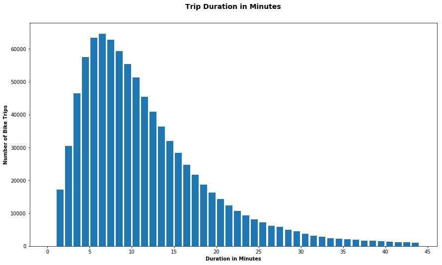

```python
# Duration of the bike rides -in MINUTES
plt.figure(figsize=[14.70, 8.27])
bin_edges = np.arange(0, 45, 1) # Changed axis limit to see the shape where most data points lie.
ticks = [0, 5, 10, 15, 20, 25, 30,  35, 40, 45]
labels = ['{}'.format(val) for val in ticks]

plt.hist(data = df_2020, x = 'duration_minutes', bins = bin_edges, rwidth = 0.8);
plt.title('Trip Duration in Minutes', y=1.05, fontsize=14, fontweight='bold')
plt.xlabel('Duration in Minutes', fontweight='bold')
plt.xticks(ticks, labels)
plt.ylabel('Number of Bike Trips', fontweight='bold');
```

## When are most trips taken in terms of month of the year and day of the week?

Most trips are taken in February, and trips started and ended on Wednesday.

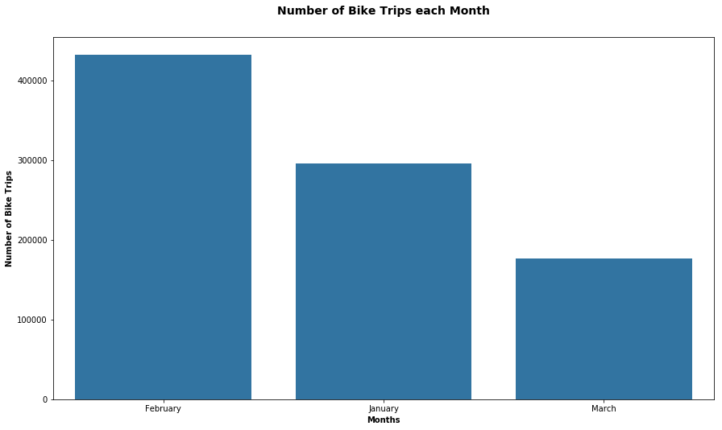

```python
plt.figure(figsize=[14.70, 8.27])
base_color = sb.color_palette()[0]
month_order = df_2020['month'].value_counts().index
sb.countplot(data = df_2020, x = 'month', color = base_color, order = month_order)
plt.title('Number of Bike Trips each Month', y=1.05, fontsize=14, fontweight='bold')
plt.xlabel('Months', fontweight='bold')
plt.ylabel('Number of Bike Trips', fontweight='bold');
```

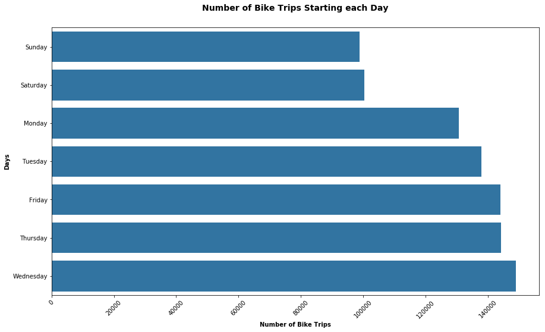

```python
plt.figure(figsize=[14.70, 8.27])
base_color = sb.color_palette()[0]
startDay_order = df_2020['start_day'].value_counts(ascending=True).index # to reverse order
sb.countplot(data = df_2020, y = 'start_day', color = base_color, order = startDay_order)
plt.title('Number of Bike Trips Starting each Day', y=1.05, fontsize=14, fontweight='bold')
plt.ylabel('Days', fontweight='bold')
plt.xlabel('Number of Bike Trips', fontweight='bold')
plt.xticks(rotation = 45);
```

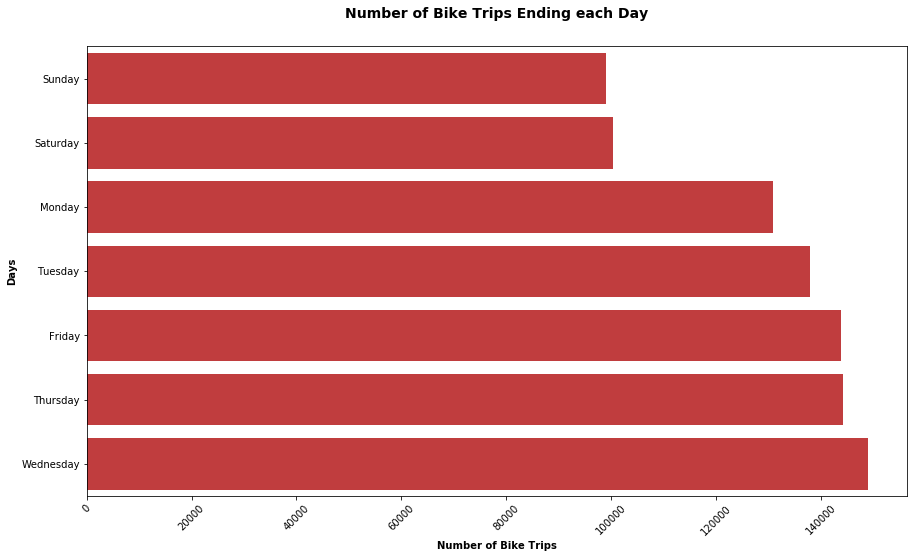

```python
plt.figure(figsize=[14.70, 8.27])
base_color = sb.color_palette()[3]
startDay_order = df_2020['end_day'].value_counts(ascending=True).index # to reverse order
sb.countplot(data = df_2020, y = 'end_day', color = base_color, order = startDay_order)
plt.title('Number of Bike Trips Ending each Day', y=1.05, fontsize=14, fontweight='bold')
plt.ylabel('Days', fontweight='bold')
plt.xlabel('Number of Bike Trips', fontweight='bold')
plt.xticks(rotation = 45);
```

## Does the trip duration depend on the user type or not?

At durations less than or equal to 60 minutes, both customers (casual) and subscribers (members) have achieved similar duartions of use.

When viewed by Month, without setting a duration limit, the plot shows that some customers had longer trip durations than subscribers.

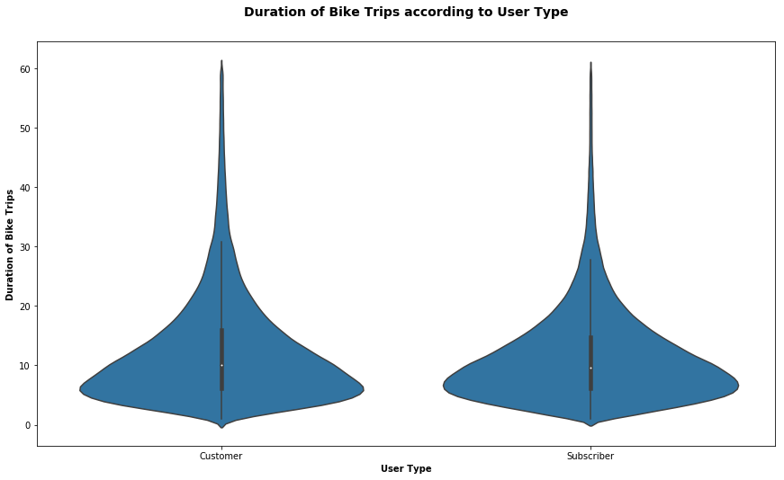

```python
# Does trip duration depend on user type?
plt.figure(figsize=[14.70, 8.27])
sb.violinplot(data = df_2020.query("duration_minutes <= 60"),x = 'user_type',y='duration_minutes',color = sb.color_palette()[0])
plt.title('Duration of Bike Trips according to User Type', y=1.05, fontsize=14, fontweight='bold')
plt.xlabel('User Type', fontweight='bold')
plt.ylabel('Duration of Bike Trips', fontweight='bold');
```

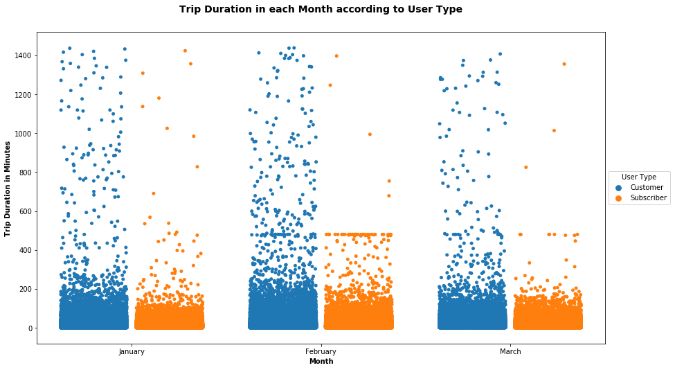

```python
# scatterplot - duration and month - by user type

plt.figure(figsize=[14.70, 8.27])
sb.stripplot(data = df_2020, x = 'month', y = 'duration_minutes', hue = 'user_type',
jitter = 0.35, dodge = True)
plt.legend(loc= 'center left', bbox_to_anchor = (1, 0.5), title = 'User Type')
plt.title('Trip Duration in each Month according to User Type', y=1.05, fontsize=14, fontweight='bold')
plt.xlabel('Month', fontweight='bold')
plt.ylabel('Trip Duration in Minutes', fontweight='bold');
```

## Is the idea succeeding?

YES!

Average Trip duration has been increasing since Jan 2020 and reached it's peak in March which concludes that people are depending more on bikes to go to farther places .

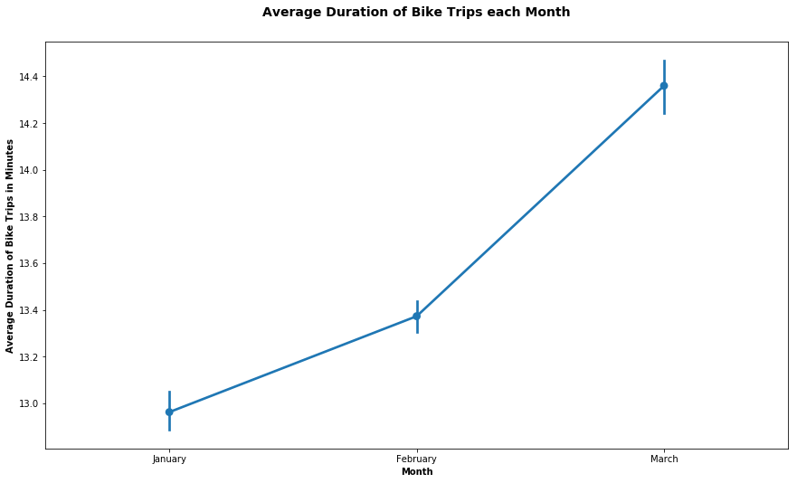

```python
# duration min against month
plt.figure(figsize=[14.70, 8.27])
base_color = sb.color_palette()[0]
sb.pointplot(data = df_2020, x = 'month', y = 'duration_minutes', color = base_color)
plt.title('Average Duration of Bike Trips each Month', y=1.05, fontsize=14, fontweight='bold')
plt.xlabel('Month', fontweight='bold')
plt.ylabel('Average Duration of Bike Trips in Minutes', fontweight='bold');
```

Once you're ready to finish your presentation, check your output by using nbconvert to export the notebook and set up a server for the slides. From the terminal or command line, use the following expression:

> `jupyter nbconvert <file_name>.ipynb --to slides --post serve --template output_toggle`

This should open a tab in your web browser where you can scroll through your presentation. Sub-slides can be accessed by pressing 'down' when viewing its parent slide. Make sure you remove all of the quote-formatted guide notes like this one before you finish your presentation!